# INE approach

Chen Ning Kuan

2019/11/29

# 1 Monte Carlo Simulations

Our estimator $\widetilde{S}(x)$ is computed from INE(Iterative Nelson Estimator) approach,you can see the approach method in section2.we now asses their performane using Monte Carlo simulation

## 1.1 Data generation process

- step1:Xi and Ti are generated independenylt from the following distributions

$$Xi\stackrel{i.i.d}{\sim} Gamma( 2,1) \quad i=1,...,n$$
$$Ti\stackrel{i.i.d}{\sim} Unif( 0,4) \quad i=1,...,n$$

$$n=100\quad sample \ size$$

- step2:If $Xi <Ti$, this observation is ignored.Otherwise,if $Xi<Ti+0.5$,we get an observation lies between two examination,say $[Ti,Ti+0.5)$;else it is right cenosred at $Ti+0.5$

Thus,we only know that $Li<=Xi<=Ui$ iff $Xi>=Ti$.It is possible that $Ui= \infty$

Write a function called “samplemaker_gamma” to make sample

```r
samplemaker_gamma <- function(n=100,shape=2,scale=1,end=4 ){
x <- rgamma(n,shape = 2,scale = 1)
t <- runif(n,0,4)
delta <- 0.5
M <- 1
observedx <- x[which(x>t)]
observedt <- t[which(x>t)]
data <- data.frame(observedx,observedt)
status <- ifelse( observedx<=observedt+M*delta, 3  , 0) #maybe change
qi <- ifelse(status==3,  observedt  ,observedt+M*delta   )
pi <- ifelse( status==3,  observedt+M*delta ,  Inf                 )
datause <- data.frame(observedx,observedt ,Li=qi,Ui=pi,status,entry=observedt)
return(datause)
}
```

```r
samplemaker_weibull<- function(n=130,shape=4,scale=1,end=1.5 ){
#n <- 500
#shape <- 4
#scale <- 1
x <- rweibull(n,shape,scale)
t <- runif(n,0,end)
delta <- 0.5
M <- 1
observedx <- x[which(x>t)]
observedt <- t[which(x>t)]
status <- ifelse( observedx<=observedt+M*delta, 3  , 0) #maybe change
qi <- ifelse(status==3,  observedt  ,observedt+M*delta   )
pi <- ifelse( status==3,  observedt+M*delta ,  Inf  )
datause <- data.frame(observedx,observedt ,Li=qi,Ui=pi,status,entry=observedt)
return(datause)
}
```

## 1.2 Simulation procedure

# 2 INE approach

Our INE approach includes 5 step:

- step 1:To construct the estimator $\widetilde{S}(x)$ , let $0 = \tau_0 < \tau_1 < \tau_2 < ...< \tau_m$ be a grid of time which includes all the points $Li,Ui$ from data.Thus,we have m interval.This method is maded by Giolo.
- step 2:For i=1,…,n. For the ith observation, define a weight $\alpha_{ij}$ to be $1$ if the interval $(\tau_{j-1},\tau_{j}]$ is contained in the interval $(L_i,U_i]$ and 0,otherwise.
- step 3:Let $r=0$;give an intitila estimate $\widetilde{S}^{(0)}$ of the survival function
- step 4:Under the current estimate of the survival function $\widetilde{S}^{(r)}$, compute $d_j$ , the expected number of deaths in each interval as in Turnbull’s self-consistency algorithm. Let $R_j=\sum_{i\geq j}d_i$

$$p_j=S(\tau_{j-1})^-S(\tau_{j})\quad j=1,...,m$$

$$d_j=\sum_{i=1}^{n}\frac{\alpha_{ij}p_j}{\sum_{k=1}^{m}\alpha_{ik}p_k}\quad j=1,...,m$$

- step 5:Estimate the hazard increment in each interval as $\widetilde{\lambda}_j=\frac{ d_j }{R_j}$ , then the cumulative hazard function is estimated by $\widetilde{\Lambda}(x)=\sum_{j:p_j\leq x}\widetilde{\lambda}_i$, and the new survival function estimate is$\widetilde{S}^{(r+1)}(x)=exp(-\widetilde{\Lambda}(x))$If $\widetilde{S}^{(r+1)}(x)$ and $\widetilde{S}^{(r)}(x)$ are close enough, stop;otherwise,let $r= r+1$ and go to Step 4.

# 3.Function for simulation

## 3.1 show the datatest

datatest is a test data (n=7)

```r
set.seed(5)
datatest <- samplemaker_gamma(n=7)
print("datatest")
```

```
## [1] "datatest"
```

```r
datatest
```

```
##   observedx observedt     Li    Ui status  entry
## 1    4.3283    2.8828 3.3828   Inf      0 2.8828
## 2    0.8525    0.8454 0.8454 1.345      3 0.8454
## 3    1.6879    0.9029 1.4029   Inf      0 0.9029
## 4    0.6517    0.5599 0.5599 1.060      3 0.5599
```

## 3.2 Write a fucntion do step 1

- step 1:To construct the estimator $\widetilde{S}(x)$ , let $0 = \tau_0 < \tau_1 < \tau_2 < ...< \tau_m$ be a grid of time which includes all the points $Li,Ui$ from data.Thus,we have m interval.This method is maded by Giolo.

```r
cria.tau <- function(data){
l <- data$Li
r <- data$Ui
tau <- sort(unique(c(l,r[is.finite(r)])))
#tau <- c( 0,tau,100000)
return(tau)
}
```

```r
print("tau")
```

```
## [1] "tau"
```

```r
cria.tau( datatest )
```

```
## [1] 0.5599 0.8454 1.0599 1.3454 1.4029 3.3828
```

write a fucntion do step 1 continue

```r
makeinterval <- function(data){
x <- matrix( c(0,rep(cria.tau( data ),rep(2,length( cria.tau( data )  ))) ,100000 )
,ncol = 2 ,byrow = T)
q <- x[,1]
p <- x[,2]
data.frame(q,p)
}
```

we show the interval in datatest

```r
makeinterval(datatest)
```

```
##        q         p
## 1 0.0000 5.599e-01
## 2 0.5599 8.454e-01
## 3 0.8454 1.060e+00
## 4 1.0599 1.345e+00
## 5 1.3454 1.403e+00
## 6 1.4029 3.383e+00
## 7 3.3828 1.000e+05
```

## 3.3 Write a fucntion do step 2

- step 2:for i = 1, . . . , n. For the ith observation, define a weight $\alpha_{ij}$ to be $1$ if the interval $(\tau_{j-1},\tau_{j}]$ is contained in the interval $(L_i,U_i]$ and 0,otherwise.

```r
make_A_turnbull <- function(datacheck){
  qj<- makeinterval(datacheck)$q
  pj<- makeinterval(datacheck)$p
  li <- datacheck$Li
  ri <- datacheck$Ui
  n <- length(li)
  m <- length(pj)
  A <- matrix(0,nrow = n,ncol = m)
  intmapL <- signif(qj,4)
  intmapR <- signif(pj,4)
  k <- dim(A)[[2]]
  Lbracket <- rep("(", k)
  Rbracket <- rep(")", k)
  intname <- paste(Lbracket, intmapL, ",", intmapR, Rbracket,
  sep = "")

  intmapL2 <- signif(datacheck$Li, 4)
  intmapR2 <- signif(datacheck$Ui, 4)
  k2 <- dim(A)[[1]]
  Lbracket2 <- rep("(", k2)
  Rbracket2 <- rep(")", k2)
  intname2 <- paste(Lbracket2, intmapL2, ",", intmapR2, Rbracket2,
  sep = "")
  for(j in 1:m){
    for( i in 1:n){
      if( li[i]<=qj[j]&&ri[i]>=pj[j]      ){
        A[i,j] <- 1
      }
      else{A[i,j] <- 0}
    }
  }

colnames(A) <- intname
rownames(A) <- intname2
return(A)
}
```

we show the corrsponding $\alpha_{ij}$ in datatest

```r
datatest_A <- make_A_turnbull(datatest)
datatest_A
```

```
##                (0,0.5599) (0.5599,0.8454) (0.8454,1.06) (1.06,1.345)
## (3.383,Inf)             0               0             0            0
## (0.8454,1.345)          0               0             1            1
## (1.403,Inf)             0               0             0            0
## (0.5599,1.06)           0               1             1            0
##                (1.345,1.403) (1.403,3.383) (3.383,1e+05)
## (3.383,Inf)                0             0             1
## (0.8454,1.345)             0             0             0
## (1.403,Inf)                0             1             1
## (0.5599,1.06)              0             0             0
```

## 3.4 Write a fucntion do step 4 and step 5

- step 4:Under the current estimate of the survival function $\widetilde{S}^{(r)}$, compute $d_j$ , the expected number of deaths in each interval as in Turnbull’s self-consistency algorithm. Let $R_j=\sum_{i\geq j}d_i$

$$p_j=S(\tau_{j-1})^-S(\tau_{j})\quad j=1,...,m$$

$$d_j=\sum_{i=1}^{n}\frac{\alpha_{ij}p_j}{\sum_{k=1}^{m}\alpha_{ik}p_k}\quad j=1,...,m$$

- step 5:Estimate the hazard increment in each interval as $\widetilde{\lambda}_j=\frac{ d_j }{R_j}$ , then the cumulative hazard function is estimated by $\widetilde{\Lambda}(x)=\sum_{j:p_j\leq x}\widetilde{\lambda}_j$, and the new survival function estimate is$\widetilde{S}^{(r+1)}(x)=exp(-\widetilde{\Lambda}(x))$If $\widetilde{S}^{(r+1)}(x)$ and $\widetilde{S}^{(r)}(x)$ are close enough, stop;otherwise,let $r= r+1$ and go to Step 4.

```r
#data <- samplemaker_gamma()

myfunction_turnbull<- function(data,iter.max=2000){

A <- Aintmap(L= data$Li,R=data$Ui)$A
tau <-Aintmap(L= data$Li,R=data$Ui)$intmap[2,]
#A
s <- rep(   1/dim(A)[2],  dim(A)[2] )  #give initail guess
eps=0.00001    #tolerance
n<-nrow(A)     #number of observation
m<-ncol(A)     #number of interval
S=cumsum(s)
S=S[m:1]
#S
Q<-matrix(1,m)
#Q
#length(S)
#dim(A)
iter <- 0
repeat {

iter <- iter + 1
diff<- (Q-S)
#diff
maxdiff<-max(abs(as.vector(diff)))
#maxdiff

if (maxdiff<eps|iter>=iter.max)
  break
Q <- S
#Q
#s
#length(p)
#dim(A)
#s
den <- rep(0,n)
densum <- rep(0,n)
d<- rep(0,m)
###compute expected death
for(j in 1:m){

for(i in 1:n){

  if(A[i,j]>0){

  den[i]<- sum(A[i,]*s)
  densum[i]<- A[i,j]*s[j]/den[i]
  d[j]<- sum( densum )
  }
}

}

###compute expected death
#d

Rj <-NULL
for(j in 1:m){

 Rj [j]<- sum( d[j:m]   )
}

lamdatelta <- d/Rj
#lamdatelta
cumlatedhazard<- cumsum(lamdatelta)
#cumlatedhazard
S<-exp(-cumlatedhazard )
#S
SS<- S
SS[m] <- 0

#c(1,S[1:m-1])-SS

s <- c(1,S[1:m-1])-SS
#s
#sum(s)
S[1] <- 1
S[m] <- 0
}
#tau
c <- data.frame(tau,S)
return(c)

}
```

# 4 simulation rusult

## R=1 case

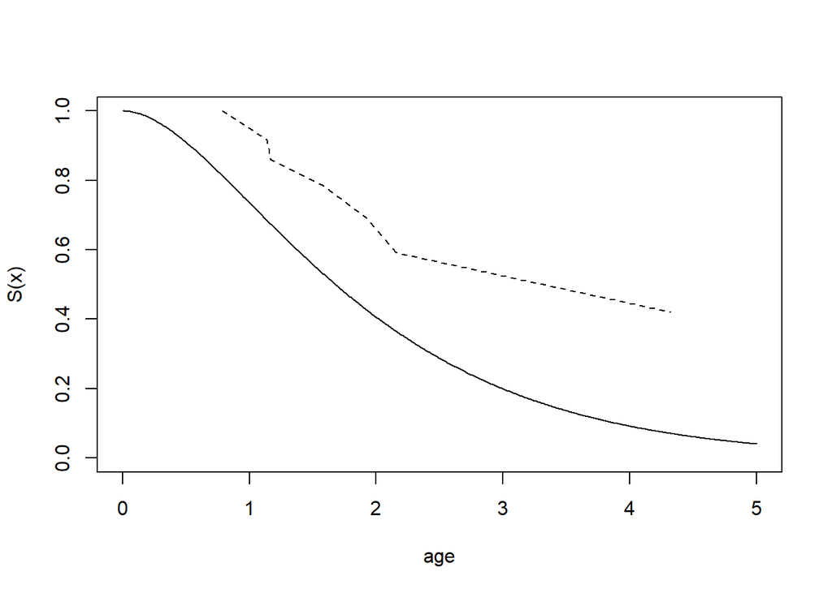

```r
b <- myfunction_turnbull(  samplemaker_gamma(n=100))
plot(b$tau,b$S,type = "l",lty=2,c(0,5),xlab = "age",ylab="S(x)")
x = seq(0, 5, 0.01)
shape = 2
rate = 1
cdf2 = pgamma(x, shape, scale = 1)
lines(x,1-cdf2)
```

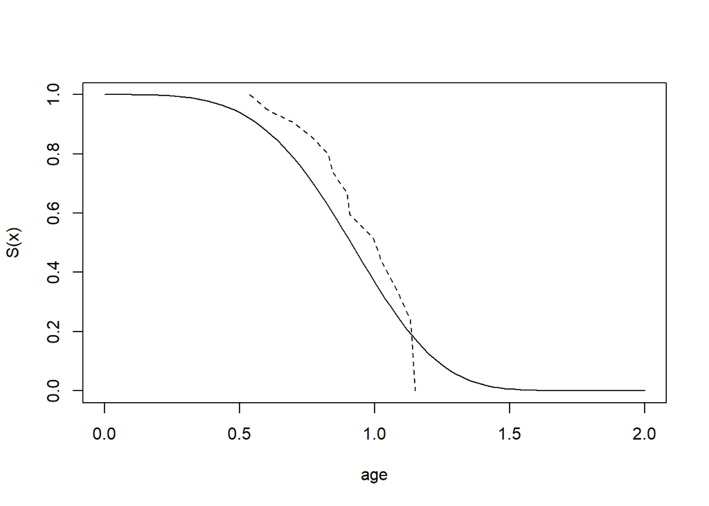

```r
a <- myfunction_turnbull(  samplemaker_weibull(  ))

plot(a$tau,a$S,type = "l",lty=2,xlim = c(0,2),xlab = "age",ylab="S(x)")
curve(exp(-(x/1)^4),from=0,to=2,add = T)
```

the function do the interpolation

```r
myexperiment_gamma=function(n=100 ){
xout <- seq(0,5,0.01)
data <- samplemaker_gamma(n)
aa <- myfunction_turnbull(data)
#plot(aa$tau,aa$S,type = "l",col="blue",lty=2)
#lines(x,1-cdf,col="green")
#length(aa$tau)
#length(aa$p)
approx_y <- approx(aa$tau,aa$S, xout=xout,yleft=1 ,yright=0 )
approx_y <- approx_y$y
#plot(xout,approx_y ,type = "l",col="blue",lty=2 )
#lines(x,1-cdf,col="green")
return(approx_y)
}
```

## R=500 case

```r
R=500
x = seq(0, 5, 0.01)
# Now define the parameters of your gamma distribution
shape = 2
rate = 1
# Now calculate points on the cdf
cdf = pgamma(x, shape, rate)
# Shown plotted here
x = seq(0, 5, 0.01)
par(mfrow=c(1,1))
xout <- seq(0,5,0.01)
dd <- replicate(n=R, myexperiment_gamma(n=100 ))
order <- t(apply(dd,1,sort))
mean <- apply(order,1,mean)
plot(xout,mean,type = "l",col="blue",lty=2,main="gamma(shape=2,sclae=1,R=500,n=100)",xlim = c(0,5),ylim = c(0,1))
lines(x,1-cdf,col="green")
lines(xout,order[,round(R*0.025)] , col="blue",lty=3  )
#lines(xout,order[,round(R*0.2)] , col="blue",lty=3)
lines(xout,order[,round(R*0.975)] , col="blue",lty=3  )
```

[output not shown]